# COD_20231115_MGK_IBS7048_week12_DA_analysis

Minsik Kim

2023-11-15

This analysis pipe noted https://github.com/minsiksudo/BTE3207_Advanced_Biostatistics.

# Roading the data

from previous lecture.. we generated a phyloseq object. it can be saved to hard disk using the below command.

`saveRDS(ps, "phyloseq_example.rds")`

And it can be loaded to a new R session like below!

```r
getwd()
```

```
## [1] "/Users/minsikkim/Dropbox (Personal)/Inha/5_Lectures/Advanced metagenomics/scripts/IBS7048_Advanced_metagenomics"
```

```r
library(phyloseq)
library(tidyverse)
library(microbiome)
library(vegan)
library(ggplot2)
#source("https://raw.githubusercontent.com/joey711/phyloseq/master/inst/scripts/installer.R",
#       local = TRUE)


phyloseq <- readRDS("/Users/minsikkim/Dropbox (Personal)/Inha/5_Lectures/Advanced metagenomics/scripts/IBS7048_Advanced_metagenomics/phyloseq_example.rds")


phyloseq_rel <- transform_sample_counts(phyloseq, function(x){x/sum(x)})
```

# Recall

From the barplot…

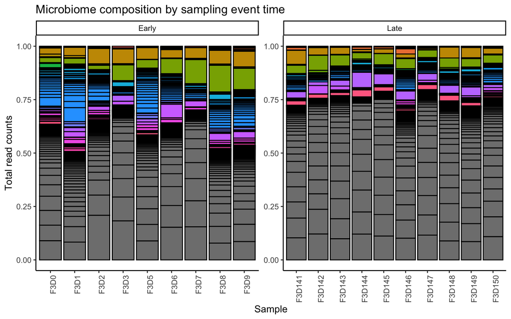

```r
# Create a df with all `Top 10 Genus` and flag the top 20


plot_bar(phyloseq_rel, fill = "Genus") +
        ylab("Total read counts") +
        theme_classic() +
        theme(axis.text.x = element_text(angle = 90),
              legend.position = "none") +
        #scale_fill_brewer(type = "qual", palette = 3) +
        facet_wrap(~When, scales = "free") +
        ggtitle("Microbiome composition by sampling event time")
```

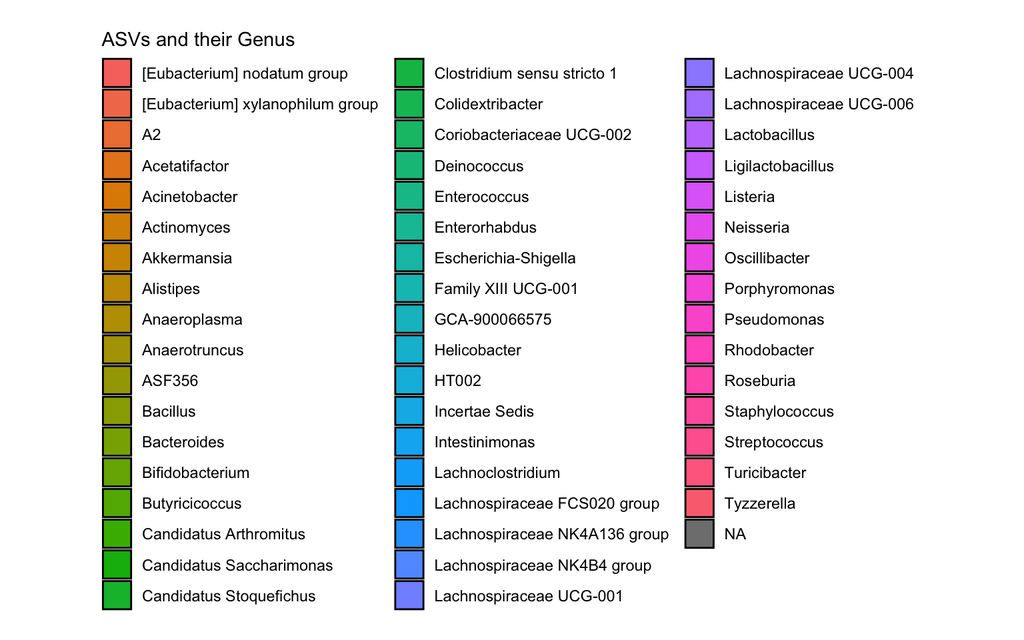

```r
cowplot::get_legend(
plot_bar(phyloseq_rel, fill = "Genus") +
        ylab("Total read counts") +
        theme_classic() +
        theme(axis.text.x = element_text(angle = 90)) +
        labs(fill = "ASVs and their Genus") +
        #scale_fill_brewer(type = "qual", palette = 3) +
        facet_wrap(~When, scales = "free") +
        ggtitle("Microbiome composition by sampling event time")
) %>%
        ggpubr::as_ggplot()
```

Can you see the difference?

# Differential abundance analysis using your model

## Using linear models 1

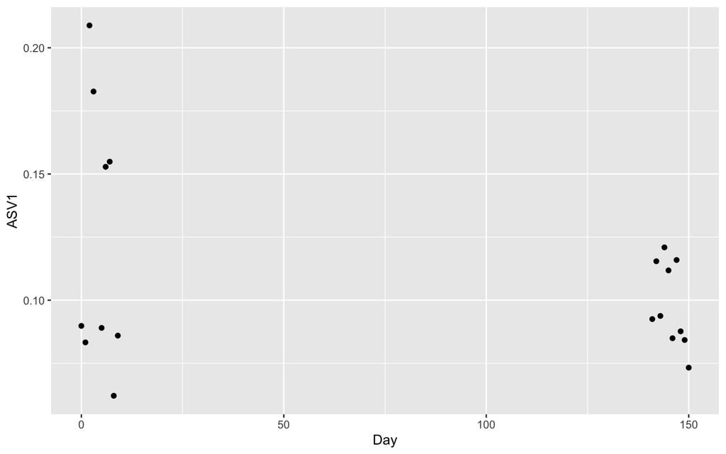

```r
#Loading OTU table

otu_table <- phyloseq_rel %>% otu_table %>% t

#tax table for different sample type
taxa_data <- otu_table[1] %>% t %>% data.frame()

#Making a merged dataframe having sample data and CLR transformed output
lme_data <- merge(taxa_data, sample_data(phyloseq_rel), by = 0) %>% column_to_rownames("Row.names")


ggplot(lme_data, aes(x = Day, y = ASV1)) +
        geom_point()
```

It looks like ther is some difference (in ther relative abundacnes)

Can we test them?

```r
lm(ASV1 ~ When, data = lme_data) %>%
        summary()
```

```
##
## Call:
## lm(formula = ASV1 ~ When, data = lme_data)
##
## Residuals:
##       Min        1Q    Median        3Q       Max
## -0.061144 -0.029114 -0.005525  0.020382  0.085583
##
## Coefficients:
##             Estimate Std. Error t value Pr(>|t|)
## (Intercept)  0.12328    0.01258   9.799 2.08e-08 ***
## WhenLate    -0.02523    0.01734  -1.455    0.164
## ---
## Signif. codes:  0 '***' 0.001 '**' 0.01 '*' 0.05 '.' 0.1 ' ' 1
##
## Residual standard error: 0.03774 on 17 degrees of freedom
## Multiple R-squared:  0.1107, Adjusted R-squared:  0.05842
## F-statistic: 2.117 on 1 and 17 DF,  p-value: 0.1639
```

THe difference is not significant

## Using linear models 2

How does it look like with the second ASV

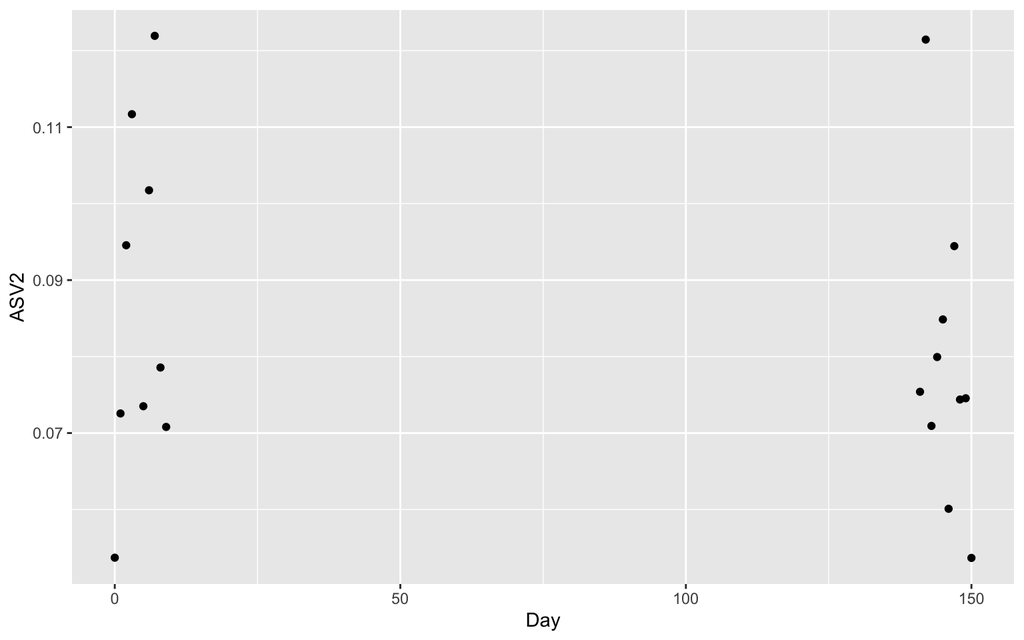

```r
#Loading OTU table

otu_table <- phyloseq_rel %>% otu_table %>% t

#tax table for different sample type
taxa_data <- otu_table[2] %>% t %>% data.frame()

#Making a merged dataframe having sample data and CLR transformed output
lme_data <- merge(taxa_data, sample_data(phyloseq_rel), by = 0) %>% column_to_rownames("Row.names")


ggplot(lme_data, aes(x = Day, y = ASV2)) +
        geom_point()
```

How about statistics?

```r
lm(ASV2 ~ When, data = lme_data) %>%
        summary()
```

```
##
## Call:
## lm(formula = ASV2 ~ When, data = lme_data)
##
## Residuals:
##       Min        1Q    Median        3Q       Max
## -0.032858 -0.013527 -0.004422  0.011586  0.042471
##
## Coefficients:
##              Estimate Std. Error t value Pr(>|t|)
## (Intercept)  0.086563   0.006825  12.682  4.3e-10 ***
## WhenLate    -0.007591   0.009408  -0.807    0.431
## ---
## Signif. codes:  0 '***' 0.001 '**' 0.01 '*' 0.05 '.' 0.1 ' ' 1
##
## Residual standard error: 0.02048 on 17 degrees of freedom
## Multiple R-squared:  0.03688,    Adjusted R-squared:  -0.01977
## F-statistic: 0.651 on 1 and 17 DF,  p-value: 0.4309
```

No difference…

# Can we run all the statistical test at once?

## Introduction to for loop

```r
for(i in 1:10) {
        print(i)
}
```

```
## [1] 1
## [1] 2
## [1] 3
## [1] 4
## [1] 5
## [1] 6
## [1] 7
## [1] 8
## [1] 9
## [1] 10
```

```r
x = 0

for(i in 1:10) {
        x <- x + i
        print(x + i)
}
```

```
## [1] 2
## [1] 5
## [1] 9
## [1] 14
## [1] 20
## [1] 27
## [1] 35
## [1] 44
## [1] 54
## [1] 65
```

## For-loop for analysis result

THis is the example code for running lm test for the 1st ASV.

```r
#with all samples

lm_taxa_all <- data.frame()

for(i in 1:1) {
        #Creating a data frame that includes CLR transformed data of i-th bug.
        #making differnt otu tables for each sample type
        otu_table <- phyloseq_rel %>% otu_table

        #tax table for different sample type
        taxa_data <- otu_table[,i] %>% data.frame()

        #Making a merged dataframe having sample data and CLR transformed output
        lm_data <- merge(taxa_data, sample_data(phyloseq_rel), by = 0) %>% column_to_rownames("Row.names")

        #generating a character of formula.
        #Here, as the taxa are already CLR transformed, I did not make model at log-scale.
        lmformula <- paste(names(taxa_data), "~", "When")

        #BAL stratified analysis
        all_result <- lm(formula = lmformula,
                                 data = lm_data) %>%
                summary %>%
                .$coefficients %>%
                data.frame(check.names = F) %>%
                mutate(feature = names(taxa_data)) %>%
                rownames_to_column("value") %>%
                .[2,] %>%
                remove_rownames()
        #row binding all the associations of i-th taxa to one data frame
        lm_taxa_all <- rbind(lm_taxa_all,
                               all_result) %>%
                remove_rownames()

}

head(lm_taxa_all)
```

```
##      value    Estimate Std. Error   t value  Pr(>|t|) feature
## 1 WhenLate -0.02523023 0.01734153 -1.454903 0.1639126    ASV1
```

## For-loop for DA analysis

By changing the number of for loop, we can run multiple test and aggregate the result into one dataframe.

```r
#with all samples

lm_taxa_all <- data.frame()

all <- phyloseq_rel %>% taxa_sums() %>% length()

for(i in 1:all) {
        #Creating a data frame that includes CLR transformed data of i-th bug.
        #making differnt otu tables for each sample type
        otu_table <- phyloseq_rel %>% otu_table

        #tax table for different sample type
        taxa_data <- otu_table[,i] %>% data.frame()

        #Making a merged dataframe having sample data and CLR transformed output
        lm_data <- merge(taxa_data, sample_data(phyloseq_rel), by = 0) %>% column_to_rownames("Row.names")

        #generating a character of formula.
        #Here, as the taxa are already CLR transformed, I did not make model at log-scale.
        lmformula <- paste(names(taxa_data), "~", "When")

        #BAL stratified analysis
        all_result <- lm(formula = lmformula,
                                 data = lm_data) %>%
                summary %>%
                .$coefficients %>%
                data.frame(check.names = F) %>%
                mutate(feature = names(taxa_data)) %>%
                rownames_to_column("value") %>%
                .[2,] %>%
                remove_rownames()
        #row binding all the associations of i-th taxa to one data frame
        lm_taxa_all <- rbind(lm_taxa_all,
                               all_result) %>%
                remove_rownames()

}

head(lm_taxa_all)
```

```
##      value     Estimate  Std. Error    t value     Pr(>|t|) feature
## 1 WhenLate -0.025230234 0.017341527 -1.4549027 1.639126e-01    ASV1
## 2 WhenLate -0.007591208 0.009408264 -0.8068660 4.308881e-01    ASV2
## 3 WhenLate -0.002902008 0.006347035 -0.4572227 6.532998e-01    ASV3
## 4 WhenLate  0.049923591 0.007639995  6.5345057 5.098529e-06    ASV4
## 5 WhenLate -0.021115907 0.013164545 -1.6039982 1.271301e-01    ASV5
## 6 WhenLate  0.067059346 0.009262459  7.2399073 1.382214e-06    ASV6
```

# Multple testing correction

Since we tested multiple tests at once, the p-value needs to be adjusted

```r
lm_taxa_all <- lm_taxa_all %>%
        subset(., !is.nan(.$`Pr(>|t|)`)) %>%
        mutate(qval = qvalue::qvalue(`Pr(>|t|)`, lambda = 0)$qvalue,
               p_bh = p.adjust(p = `Pr(>|t|)`, method = "BH"))
#Benjamini-Hochberg correction



head(lm_taxa_all)
```

```
##      value     Estimate  Std. Error    t value     Pr(>|t|) feature
## 1 WhenLate -0.025230234 0.017341527 -1.4549027 1.639126e-01    ASV1
## 2 WhenLate -0.007591208 0.009408264 -0.8068660 4.308881e-01    ASV2
## 3 WhenLate -0.002902008 0.006347035 -0.4572227 6.532998e-01    ASV3
## 4 WhenLate  0.049923591 0.007639995  6.5345057 5.098529e-06    ASV4
## 5 WhenLate -0.021115907 0.013164545 -1.6039982 1.271301e-01    ASV5
## 6 WhenLate  0.067059346 0.009262459  7.2399073 1.382214e-06    ASV6
##           qval         p_bh
## 1 0.3247614964 0.3247614964
## 2 0.4991709066 0.4991709066
## 3 0.6924978165 0.6924978165
## 4 0.0002161776 0.0002161776
## 5 0.2848574361 0.2848574361
## 6 0.0001465147 0.0001465147
```

To visualize the output.

volcano plot

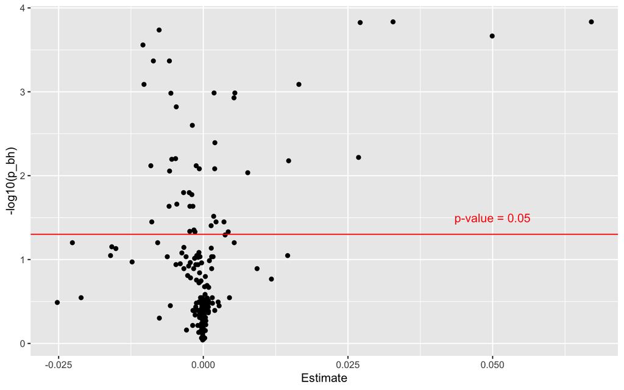

```r
ggplot(lm_taxa_all, aes(x = Estimate, y = -log10(p_bh))) +
        geom_point() +
        geom_hline(yintercept = -log10(0.05), col = "red") +
        annotate("text", x = 0.05, y = 1.5, label = "p-value = 0.05", col = "red")
```

It looks weird, as we only tested the relative abundance!

## For-loop for DA analysis (transformed data)

We can make CLR transfomred data, to consider the caveat of relative abundance

```r
phyloseq_clr <- microbiome::transform(phyloseq, transform = "clr")

#with all samples

lm_taxa_all <- data.frame()

all <- phyloseq_clr %>% taxa_sums() %>% length()

for(i in 1:all) {
        #Creating a data frame that includes CLR transformed data of i-th bug.
        #making differnt otu tables for each sample type
        otu_table <- phyloseq_clr %>% otu_table

        #tax table for different sample type
        taxa_data <- otu_table[,i] %>% data.frame()

        #Making a merged dataframe having sample data and CLR transformed output
        lm_data <- merge(taxa_data, sample_data(phyloseq_clr), by = 0) %>% column_to_rownames("Row.names")

        #generating a character of formula.
        #Here, as the taxa are already CLR transformed, I did not make model at log-scale.
        lmformula <- paste(names(taxa_data), "~", "When")

        #BAL stratified analysis
        all_result <- lm(formula = lmformula,
                                 data = lm_data) %>%
                summary %>%
                .$coefficients %>%
                data.frame(check.names = F) %>%
                mutate(feature = names(taxa_data)) %>%
                rownames_to_column("value") %>%
                .[2,] %>%
                remove_rownames()
        #row binding all the associations of i-th taxa to one data frame
        lm_taxa_all <- rbind(lm_taxa_all,
                               all_result) %>%
                remove_rownames()

}


lm_taxa_all <- lm_taxa_all %>%
        subset(., !is.nan(.$`Pr(>|t|)`)) %>%
        mutate(qval = qvalue::qvalue(`Pr(>|t|)`, lambda = 0)$qvalue,
               p_bh = p.adjust(p = `Pr(>|t|)`, method = "BH"))
#Benjamini-Hochberg correction



head(lm_taxa_all)
```

```
##      value   Estimate Std. Error   t value     Pr(>|t|) feature         qval
## 1 WhenLate 0.10211879  0.2343786 0.4357000 6.685362e-01    ASV1 0.8281112120
## 2 WhenLate 0.17875798  0.2171687 0.8231294 4.218316e-01    ASV2 0.6220427897
## 3 WhenLate 0.23437974  0.1929377 1.2147951 2.410485e-01    ASV3 0.4047456597
## 4 WhenLate 1.12402925  0.2423343 4.6383407 2.350677e-04    ASV4 0.0017630077
## 5 WhenLate 0.05008611  0.3177319 0.1576364 8.766005e-01    ASV5 0.9273201971
## 6 WhenLate 3.61718038  0.7028486 5.1464577 8.075004e-05    ASV6 0.0009562504
##           p_bh
## 1 0.8281112120
## 2 0.6220427897
## 3 0.4047456597
## 4 0.0017630077
## 5 0.9273201971
## 6 0.0009562504
```

volcano plot

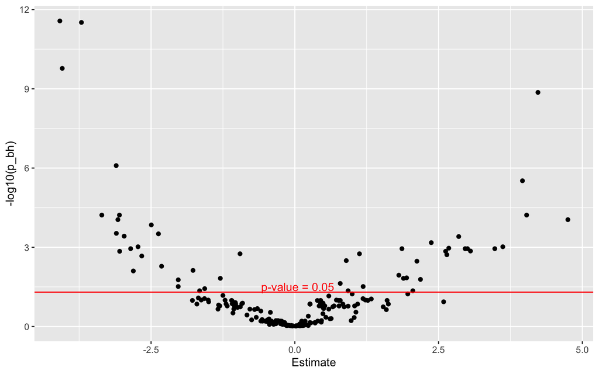

```r
ggplot(lm_taxa_all, aes(x = Estimate, y = -log10(p_bh))) +
        geom_point() +
        geom_hline(yintercept = -log10(0.05), col = "red") +
        annotate("text", x = 0.05, y = 1.5, label = "p-value = 0.05", col = "red")
```

Volcano plot looks ok.

# Using MaAslin

MaAsLin2 is comprehensive R package for efficiently determining multivariable association between phenotypes, environments, exposures, covariates and microbial meta’omic features. MaAsLin2 relies on general linear models to accommodate most modern epidemiological study designs, including cross-sectional and longitudinal, and offers a variety of data exploration, normalization, and transformation methods.

https://huttenhower.sph.harvard.edu/maaslin/

```r
if (!require("BiocManager", quietly = TRUE))
    install.packages("BiocManager")

BiocManager::install("Maaslin2")


library(Maaslin2)
```

Running maaslin

```r
capture.output(
        maaslin_output<-
                Maaslin2(input_data = otu_table(phyloseq_rel) %>%
                                 data.frame(),
                         input_metadata = phyloseq_rel %>%
                                 sample_data %>%
                                 data.frame(check.names = F),
                output = paste0(getwd(), "/maaslin_output") ,
                fixed_effects = c("When"),
                transform = "LOG", #default
                normalization = "TSS", #Choose your own normalization method
                reference = c("When,Early")))
```

[output not shown]

[output cut: 296 more lines]

```r
maaslin_all <- read.csv(paste0(getwd(), "/maaslin_output/all_results.tsv"), sep = "\t")

head(maaslin_all)
```

```
##   feature metadata value      coef    stderr  N N.not.0         pval
## 1   ASV41     When  Late -2.306703 0.2261749 19       9 1.159387e-08
## 2   ASV36     When  Late -3.361515 0.3657296 19      12 5.251227e-08
## 3   ASV50     When  Late -3.342318 0.3553378 19      11 3.769650e-08
## 4   ASV61     When  Late  2.826934 0.3068431 19      10 5.077002e-08
## 5   ASV44     When  Late -3.144538 0.3718139 19      12 1.698523e-07
## 6   ASV25     When  Late -3.885594 0.4924141 19      14 4.398006e-07
##           qval
## 1 2.052115e-06
## 2 2.323668e-06
## 3 2.323668e-06
## 4 2.323668e-06
## 5 6.012771e-06
## 6 1.112067e-05
```

Volcano plot of MaAslin output

[figure not shown]

```r
ggplot(maaslin_all, aes(x = coef, y = -log10(qval))) +
        geom_point() +
        geom_hline(yintercept = -log10(0.05), col = "red") +
        annotate("text", x = 0.1, y = 1.5, label = "q-value = 0.1", col = "red")
```

```r
install.packages("devtools")
```

[figure not shown]

```r
library(devtools)

devtools::install_github("slowkow/ggrepel")


library(ggrepel)

ggplot(maaslin_all, aes(x = coef, y = -log10(qval))) +
        geom_point() +
        geom_hline(yintercept = -log10(0.05), col = "red") +
        annotate("text", x = 0.1, y = 1.5, label = "q-value = 0.1", col = "red") +
        geom_text_repel(aes(label = feature)) +
        theme_classic()
```

# Using SIAMCAT

Due to limited number of samples / metadat in our dataset, we are going to use examples et from SIAMCAT pacakge.

**https://siamcat.embl.de/articles/SIAMCAT_vignette.html*

```r
if (!requireNamespace("BiocManager", quietly = TRUE))
    install.packages("BiocManager")
BiocManager::install("SIAMCAT")

#or,

#require("devtools")
#devtools::install_github(repo = 'zellerlab/siamcat')

library(SIAMCAT)
```

Loading example data set

```r
data("feat_crc_zeller", package="SIAMCAT")
data("meta_crc_zeller", package="SIAMCAT")

siamcat_feature <- feat.crc.zeller
siamcat_meta <- meta.crc.zeller
```

Please note that SIAMCAT is supposed to work with relative abundances. Other types of data (e.g. counts) will also work, but not all functions of the package will result in meaningful outputs.

Checking dimensions of SIAMCAT

```r
dim(siamcat_feature)
```

```
## [1] 1754  141
```

Generating labels for SIAMCAT analysis

```r
siamcat_label <- create.label(meta=siamcat_meta,
    label='Group', case='CRC')

head(siamcat_label)
```

```
## $label
##  CCIS27304052ST-3-0  CCIS15794887ST-4-0  CCIS74726977ST-3-0  CCIS16561622ST-4-0
##                  -1                  -1                  -1                  -1
##  CCIS79210440ST-3-0  CCIS82507866ST-3-0  CCIS98482370ST-3-0  CCIS00281083ST-3-0
##                  -1                  -1                  -1                  -1
##  CCIS32452666ST-4-0  CCIS94417875ST-3-0  CCIS51667829ST-4-0  CCIS27927933ST-4-0
##                  -1                  -1                  -1                  -1
##  CCIS45571137ST-3-0  CCIS81139242ST-4-0  CCIS21126322ST-4-0  CCIS17669415ST-4-0
##                  -1                  -1                  -1                   1
##  CCIS44676181ST-4-0  CCIS29210128ST-4-0  CCIS48725289ST-4-0 CCIS64785924ST-20-0
##                  -1                  -1                   1                  -1
##  CCIS03473770ST-4-0  CCIS10706551ST-3-0  CCIS64773582ST-4-0  CCIS06260551ST-3-0
##                  -1                  -1                  -1                   1
##  CCIS40244499ST-3-0  CCIS85214191ST-3-0  CCIS08668806ST-3-0 CCIS50369211ST-20-0
##                   1                   1                  -1                  -1
##  CCIS87167916ST-4-0  CCIS94496512ST-4-0  CCIS58234805ST-4-0  CCIS91228662ST-4-0
##                   1                  -1                   1                   1
##  CCIS71301801ST-4-0  CCIS24898163ST-4-0  CCIS53355328ST-4-0  CCIS41222843ST-4-0
##                   1                  -1                   1                   1
##  CCIS81887263ST-4-0 CCIS29688262ST-20-0  CCIS87116798ST-4-0  CCIS87605453ST-4-0
##                   1                  -1                   1                   1
##  CCIS83870198ST-4-0  CCIS61287323ST-4-0  CCIS11362406ST-4-0  CCIS14449628ST-4-0
##                   1                   1                  -1                   1
##  CCIS21278152ST-4-0  CCIS25399172ST-4-0  CCIS34055159ST-4-0 CCIS76845094ST-20-0
##                   1                  -1                   1                   1
##  CCIS41548810ST-4-0  CCIS98512455ST-4-0  CCIS83445808ST-4-0  CCIS37250421ST-4-0
##                   1                   1                  -1                  -1
##  CCIS35092938ST-4-0  CCIS50148151ST-4-0  CCIS62605362ST-3-0  CCIS87252800ST-4-0
##                  -1                   1                   1                   1
## CCIS22958137ST-20-0  CCIS48507077ST-4-0  CCIS32105356ST-4-0 CCIS81710917ST-20-0
##                   1                  -1                  -1                  -1
##  CCIS16326685ST-4-0  CCIS53043478ST-4-0  CCIS98832363ST-4-0  CCIS02124300ST-4-0
##                  -1                   1                   1                  -1
##  CCIS44743950ST-4-0  CCIS10793554ST-4-0  CCIS59132091ST-4-0  CCIS96387239ST-4-0
##                  -1                  -1                   1                  -1
##  CCIS82146115ST-4-0 CCIS31434951ST-20-0  CCIS33816588ST-4-0  CCIS12656533ST-4-0
##                   1                  -1                   1                   1
##  CCIS41806458ST-4-0  CCIS53557295ST-4-0  CCIS47284573ST-4-0  CCIS76563044ST-4-0
##                  -1                  -1                   1                  -1
## CCIS93040568ST-20-0  CCIS45793747ST-4-0  CCIS95097901ST-4-0  CCIS80834637ST-4-0
```

[output cut: 25 more lines]

```
##  CCIS23164343ST-4-0  CCIS03857607ST-4-0  CCIS63448910ST-4-0  CCIS88007743ST-4-0
##                  -1                  -1                  -1                  -1
##  CCIS51595129ST-4-0  CCIS09568613ST-4-0  CCIS07539127ST-4-0  CCIS41692898ST-4-0
##                  -1                  -1                  -1                  -1
##  CCIS44093303ST-4-0  CCIS00146684ST-4-0  CCIS78100604ST-4-0  CCIS48174381ST-4-0
##                  -1                  -1                  -1                  -1
##  CCIS88317640ST-4-0
##                  -1
##
## $info
## CTR CRC
##  -1   1
##
## $type
## [1] "BINARY"
```

Creating a SIAMCAT object

```r
sc.obj <- siamcat(feat=siamcat_feature,
    label=siamcat_label,
    meta=siamcat_meta)

sc.obj
```

```
## siamcat-class object
## label()                Label object:         88 CTR and 53 CRC samples
##
## contains phyloseq-class experiment-level object @phyloseq:
## phyloseq@otu_table()   OTU Table:            [ 1754 taxa and 141 samples ]
## phyloseq@sam_data()    Sample Data:          [ 141 samples by 6 sample variables ]
```

Filtering low abundant taxta

```r
sc.obj <- filter.features(sc.obj,
    filter.method = 'abundance',
    cutoff = 0.001)
```

Testing associations

Associations between microbial species and the label can be tested with the check.associations function. The function computes for each species the significance using a non-parametric Wilcoxon test and different effect sizes for the association (e.g. AUC or fold change).

The function produces a pdf file as output, since the plot is optimized for a landscape DIN-A4 layout, but can also used to plot on an active graphic device, e.g. in RStudio. The resulting plot then looks like that:

```
## Are you sure that you want to continue? (Yes/no/cancel)
```

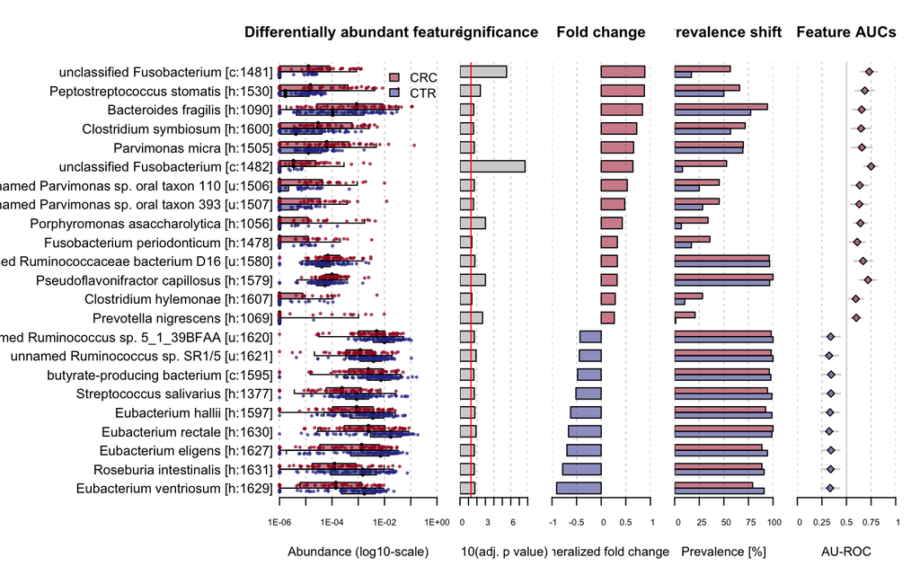

```r
sc.obj <- check.associations(sc.obj, log.n0 = 1e-06, alpha = 0.05)

association.plot(sc.obj, sort.by = 'fc',
                panels = c('fc', 'prevalence', 'auroc'))
```

Confounder testing

```r
check.confounders(sc.obj, fn.plot = 'confounder_plots.pdf',
                    meta.in = NULL, feature.type = 'filtered')
```

Data normalization

```r
sc.obj <- normalize.features(sc.obj, norm.method = "log.unit",
    norm.param = list(log.n0 = 1e-06, n.p = 2,norm.margin = 1))
```

Cross-validation preparing

```r
sc.obj <-  create.data.split(sc.obj, num.folds = 5, num.resample = 2)
```

Training model using *lasso* (least absolute shrinkage and selection operator; also Lasso or LASSO), a regression analysis method that performs both variable selection and regularization in order to enhance the prediction accuracy and interpretability of the resulting statistical model.

*Lasso* is a supervised regularization method used in *machine learning*.

`method =` specifies the type of model to be trained, may be one of these:

`c('lasso', 'enet', 'ridge', 'lasso_ll', 'ridge_ll', 'randomForest')`

```r
#Model training
sc.obj.lasso <- train.model(sc.obj, method = "lasso")
```

Model evaluation

This function calculates the Area Under the Receiver Operating Characteristic (ROC) Curve (AU-ROC) )and the Precision Recall (PR) Curve for each resampled cross-validation run.

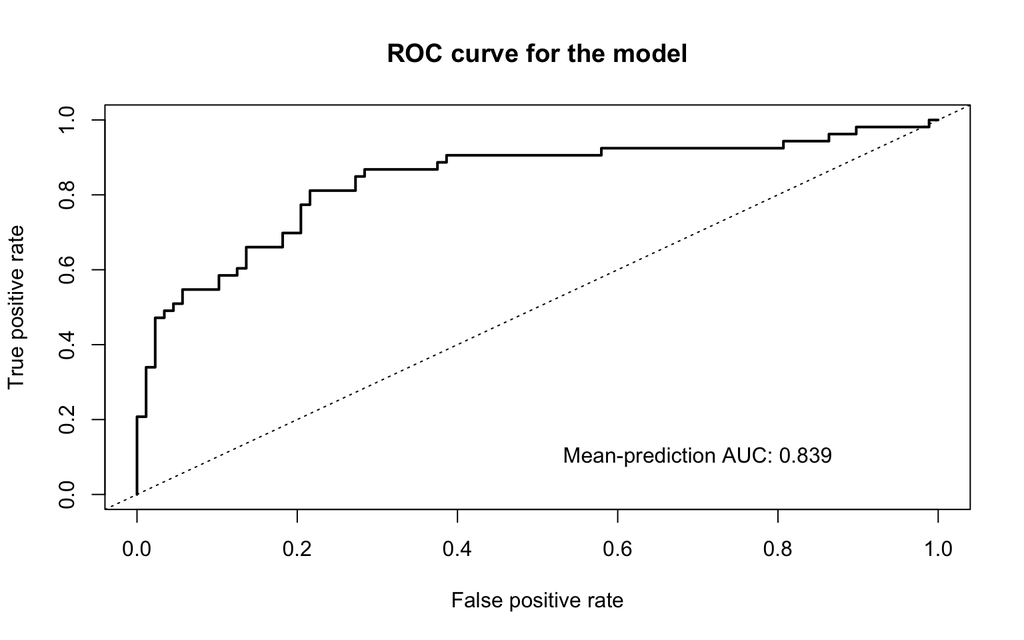

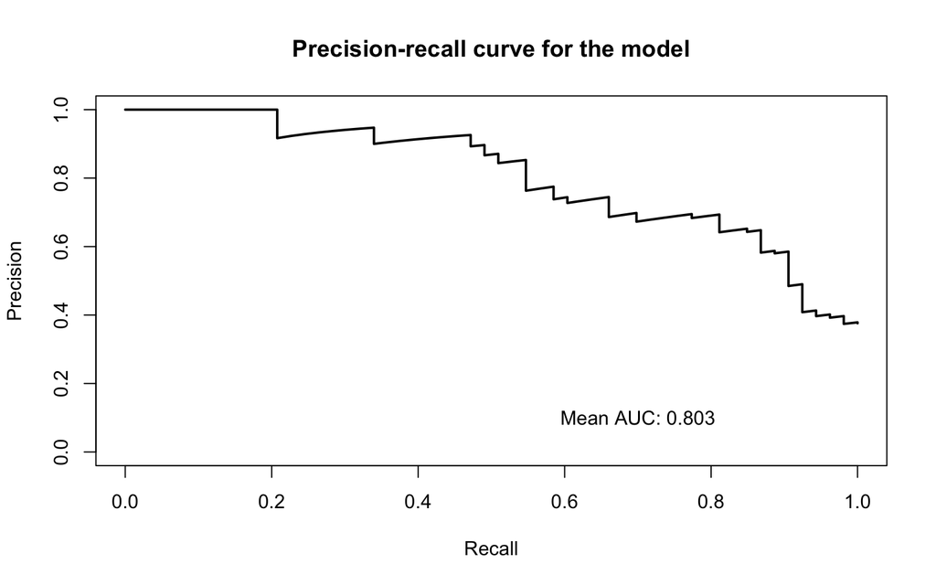

```r
#Making predictions
sc.obj.lasso <- make.predictions(sc.obj.lasso)
sc.obj.lasso <-  evaluate.predictions(sc.obj.lasso)
model.evaluation.plot(sc.obj.lasso)
```

Making interpretation plot

```r
model.interpretation.plot(sc.obj.lasso, fn.plot = 'interpretation.pdf',
    consens.thres = 0.5, limits = c(-3, 3), heatmap.type = 'zscore')
```

# Bibliography

[output not shown]